# Homework 6

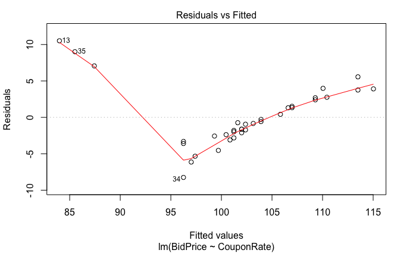

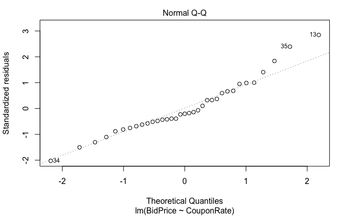

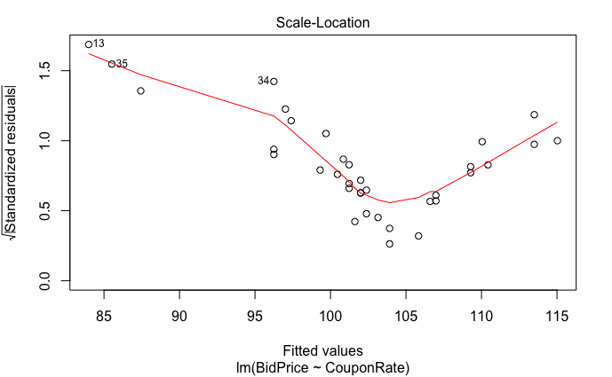

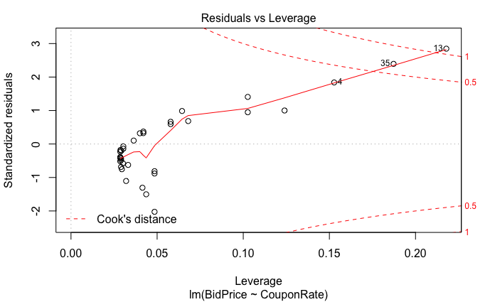

```r
plot(fit)
```

Based off the two graphs, the only point that seems to have significant influence is the 13th point in the data, which is the point where the best fit line starts.

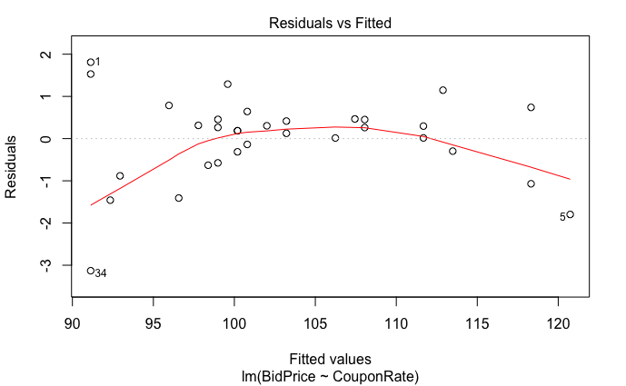

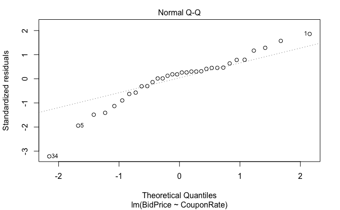

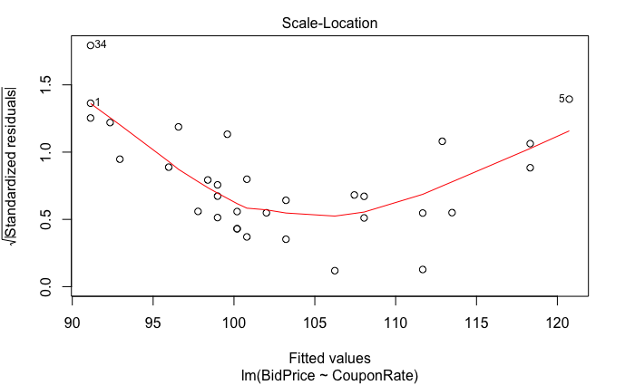

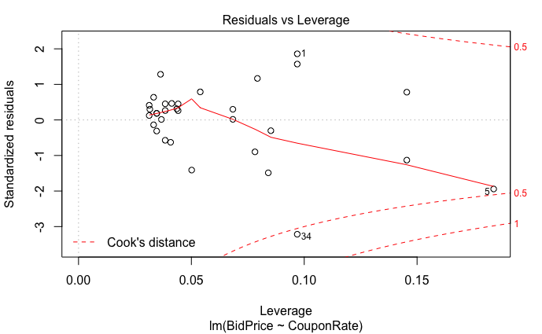

```r
bonds2 <- bonds[-c(4, 13, 35), ]
fit2 <- lm(BidPrice~CouponRate, data = bonds2)
plot(fit2)
```

```
Ignoring unknown parameters: mehtod
```

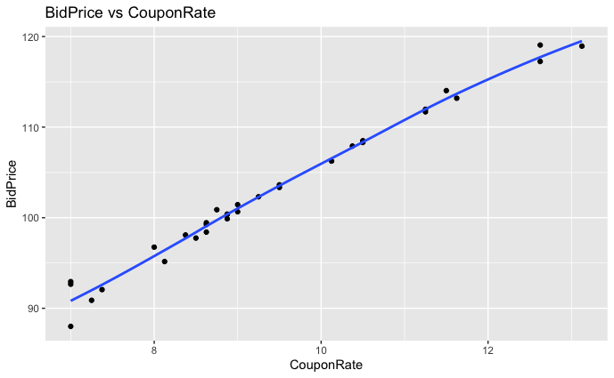

```r
bonds2 %>%
  ggplot(aes(x= CouponRate, y= BidPrice)) +
  geom_point() +
  geom_smooth(mehtod = fit, se = FALSE) +
  labs(title = "BidPrice vs CouponRate")
```

6. (3rd plot from #5)

```r
shapiro.test(rstandard(fit2))
```

```
    Shapiro-Wilk normality test

data:  rstandard(fit2)
W = 0.93145, p-value = 0.04299
```

7. Based off the test, there is cause for cocern about the normality of the data.
8. H0: B1 = 0 HA: B1 != 0

```r
summary(lm(BidPrice~CouponRate, data = bonds))
```

```
Call:
lm(formula = BidPrice ~ CouponRate, data = bonds)

Residuals:
   Min     1Q Median     3Q    Max
-8.249 -2.470 -0.838  2.550 10.515

Coefficients:
            Estimate Std. Error t value Pr(>|t|)
(Intercept)  74.7866     2.8267  26.458  < 2e-16 ***
CouponRate    3.0661     0.3068   9.994 1.64e-11 ***
---
Signif. codes:  0 ‘***’ 0.001 ‘**’ 0.01 ‘*’ 0.05 ‘.’ 0.1 ‘ ’ 1

Residual standard error: 4.175 on 33 degrees of freedom
Multiple R-squared:  0.7516,    Adjusted R-squared:  0.7441
F-statistic: 99.87 on 1 and 33 DF,  p-value: 1.645e-11
```

Based off the lm output, it seems that the relationship is positive and that there is evidence that bonds with a higher coupon rate are more expensive.

```r
newdata <- data.frame(CouponRate=0)
predict(fit, newdata = newdata, interval = "confidence", level = 0.99)
```

```
       fit      lwr     upr
1 74.78656 67.06052 82.5126
```

```r
newdata <- data.frame(CouponRate=9)
predict(fit, newdata = newdata, interval = "prediction", level = 0.99)
```

```
       fit      lwr      upr
1 102.3815 90.80667 113.9563
```

13. Good deal